# [Siwei Yang 's Data Science](https://wayag.github.io/)

Mi 19 April 2017

# [Spectral clustering and visualisation of undirected graph](https://wayag.github.io/category/r/spectral-clustering-and-visualisation-of-undirected-graph/)

Posted by [Siwei Yang](https://wayag.github.io/author/siwei-yang.html) in [R](https://wayag.github.io/category/r.html)

Since I had learned the online course [Mining of Massive Datasets](http://www.mmds.org) holded by Stanford University, I began interesting in the topic of [spectral clustering](https://en.wikipedia.org/wiki/Spectral_clustering). In that course Jure Leskovec of Stanford was able to explain the method in a very intuitve way. Given a set of persons, this method can generate different clusters or groups based on the relationship among each person. I think maybe I should do something using this approach. At the beginning, just in order to understand this method, I didn’t really want to play it with a huge dataset. One day I came up with an idea. My son is just in primary school. Maybe I can do a small experiment to generate different groups of children based on the relationship among them. This can be seen as some kind of community detection.

I decided using R to implement my idea, because I was familiar with it. As usual, at first library loading.

```r
library(data.table)
library(RColorBrewer)
library(ggplot2)
library(scatterplot3d)
library(party)
library(tabplot)
library(GGally)
library(igraph)
library(sna)
library(network)
library(visNetwork)
library(rgl)
library(rglwidget)
```

### Read data

Before the analysis, I had to take a interview with my son, because I need to know who is friend with whom. So this relationship can be represented by an ajacency matrix. It means, if Tom and David are friend with each other, then the corresponding position in the matrix is 1 , else 0. Obviously the matrix is symmetric.

Actually during the interview, my son was asked for not saying the names of his classmates, just using a index to represent each classmate. Only he knew the correspondence between the indice and the names of the 19 kids.

At first Let us take a look at the ajacency matrix `M`.

```r
M
```

```
##    1 2 3 4 5 6 7 8 9 10 11 12 13 14 15 16 17 18 19
## 1  0 0 0 0 0 0 0 1 0  0  0  1  0  0  0  1  0  1  1
## 2  0 0 0 0 0 0 0 1 0  0  0  1  0  1  0  0  0  0  0
## 3  0 0 0 1 0 0 1 0 0  0  0  0  0  0  1  0  0  0  0
## 4  0 0 1 0 1 0 1 0 0  1  0  0  0  0  0  0  0  0  0
## 5  0 0 0 1 0 0 0 1 0  0  0  1  1  0  0  0  0  0  0
## 6  0 0 0 0 0 0 0 0 1  1  0  0  0  0  0  0  0  0  0
## 7  0 0 1 1 0 0 0 0 1  1  0  0  0  0  0  0  0  0  0
## 8  1 1 0 0 1 0 0 0 0  0  0  1  0  0  0  1  1  1  1
## 9  0 0 0 0 0 1 1 0 0  0  0  0  0  0  0  0  0  0  0
## 10 0 0 0 1 0 1 1 0 0  0  0  0  0  0  0  0  0  0  0
## 11 0 0 0 0 0 0 0 0 0  0  0  0  0  0  1  0  0  0  0
## 12 1 1 0 0 1 0 0 1 0  0  0  0  0  0  0  0  0  1  1
## 13 0 0 0 0 1 0 0 0 0  0  0  0  0  0  0  0  0  0  0
## 14 0 1 0 0 0 0 0 0 0  0  0  0  0  0  0  1  0  0  0
## 15 0 0 1 0 0 0 0 0 0  0  1  0  0  0  0  0  0  0  0
## 16 1 0 0 0 0 0 0 1 0  0  0  0  0  1  0  0  1  0  0
## 17 0 0 0 0 0 0 0 1 0  0  0  0  0  0  0  1  0  1  0
## 18 1 0 0 0 0 0 0 1 0  0  0  1  0  0  0  0  1  0  1
## 19 1 0 0 0 0 0 0 1 0  0  0  1  0  0  0  0  0  1  0
```

This symmetric matrix is equivalent to a undirected graph. Using following methode the matrix can be converted to the required graph.

```r
M = as.matrix(M)
net <- graph_from_adjacency_matrix(M, mode = "undirected")
```

### Spectral clustering

In this small experiment I was going to cluster the pupils in just two groups. So based on the spectral clustering, I have to find the second smallest eigenvalue of the [Laplacian matrix](https://en.wikipedia.org/wiki/Laplacian_matrix) and its corresponding eigenvector. Checking if each component in the vector is less than 0, we get a vector `matching` respresenting which group the pupil belongs to. So far I don’t know what the two groups imply. But later its interpretation will be very obviously.

```r
D <- diag(apply(M, 1, sum))
L <- D-M
evl <- eigen(L, symmetric = TRUE)
ss = evl$vectors
secSmalleig = nrow(M) -1
matching = ifelse(ss[,secSmalleig] > 0, 1, 0) # the eigenvector corresponding to second smallest eigenvalue
```

### Some basic graphs

At first let’s make some graphs using different layouts, to gives us a basic observation. The following code is based on the [work of Katya Ognyanova](http://kateto.net/network-visualization)

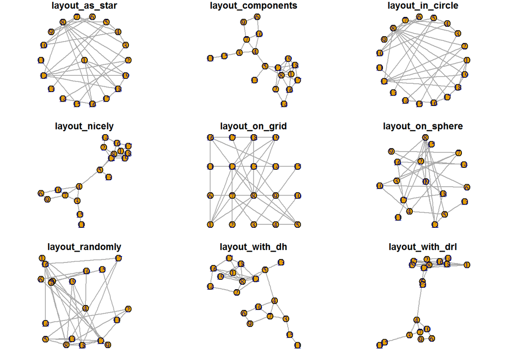

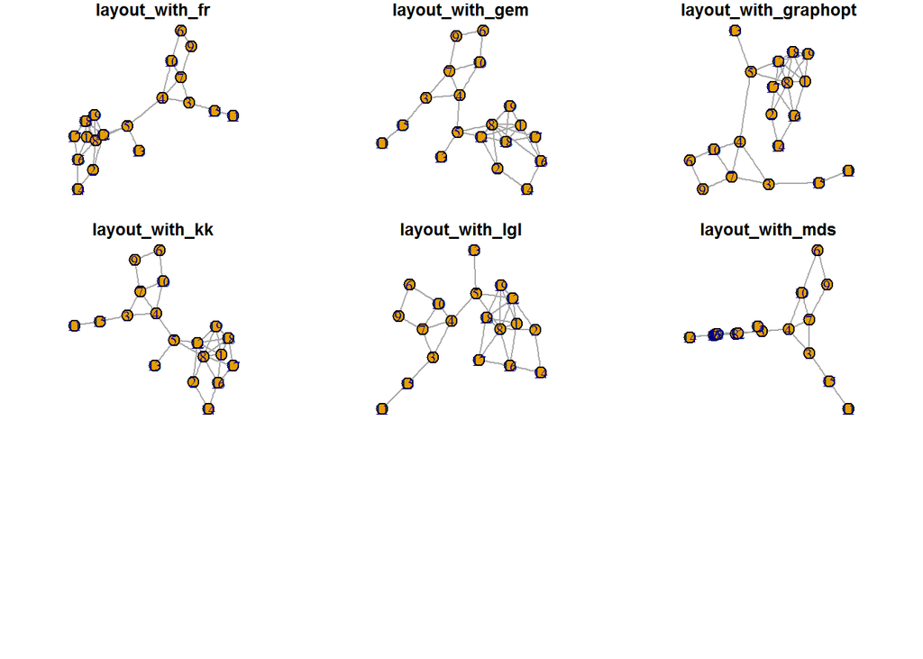

```r
layouts <- grep("^layout_", ls("package:igraph"), value=TRUE)[-1]
layouts <- layouts[!grepl("bipartite|merge|norm|sugiyama|tree", layouts)]
par(mfrow=c(3,3), mar=c(1,1,1,1))
for (layout in layouts) {
    l <- do.call(layout, list(net))
  plot(net, edge.arrow.mode=0, layout=l, main=layout) }
```

### Visualization of Clusters

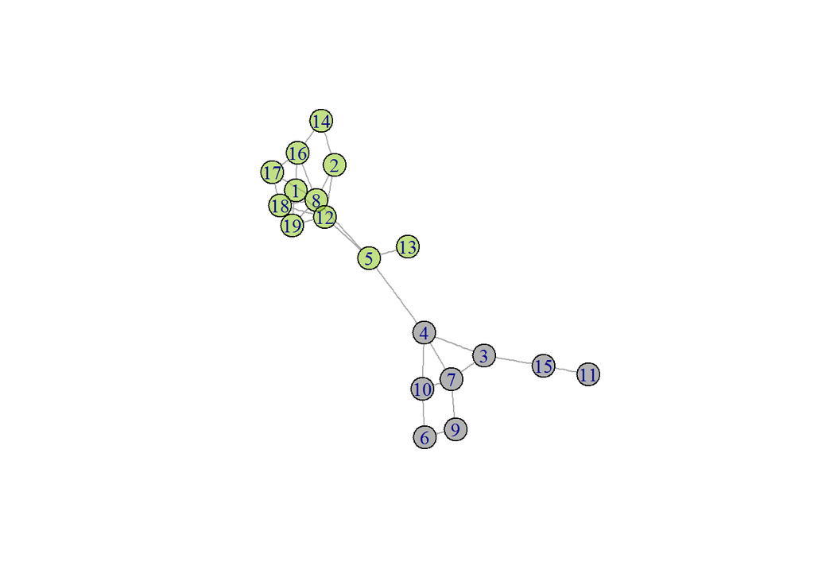

```r
# We can also plot the communities without relying on their built-in plot:
V(net)$community <- matching +1
colrs <- adjustcolor( c("gray50",  "yellowgreen"), alpha=.6)

plot(net, vertex.color=colrs[V(net)$community])
```

### Community detection using label propagation

Additionally we can do something else with the given tools. For example plot the communities using their built-in plot. As expected we got similar result like before.

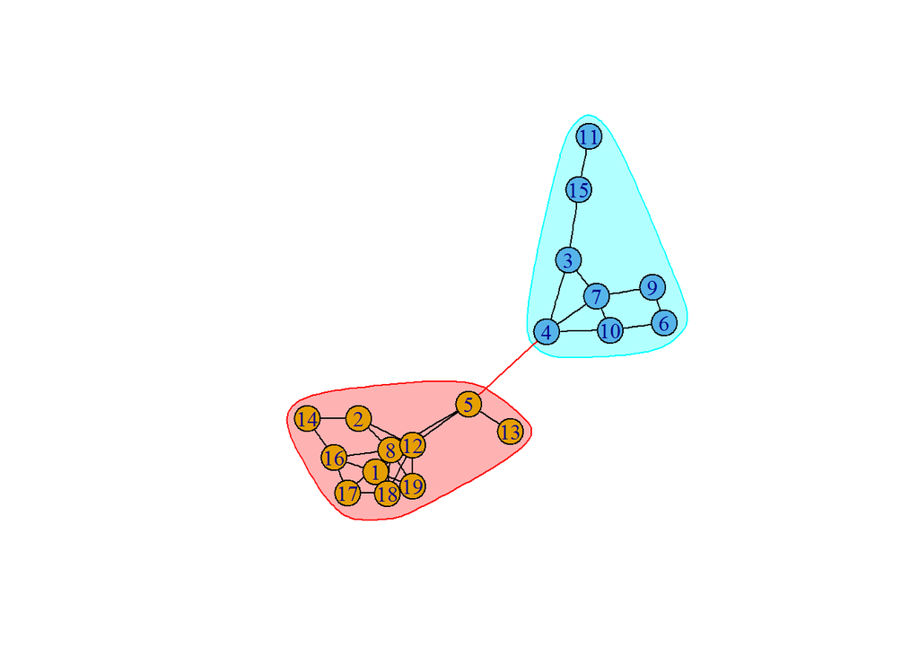

```r
# Community detection based on label propagation:
clx <- cluster_label_prop(net)
class(clx)

# Community detection returns an object of class "communities"
# which igraph knows how to plot:
plot(clx, net)
```

Because using the indice was not convenient to interpret the visuell, I was going to display the name of children. But I don’t want to publish any privacy of the children, I used pseudonym instead of their real names.

```r
namelabel = c("Tom", "David","Lilly", "Jessica","Kevin", "Laura" ,"Anne", "Jimmy", "Katherine", "Lucy", "Barbara","Anthony" ,"John","Harry","Elisabeth", "Christian","Steve" ,"Martin" ,"Jack")
```

### Interactive Visuell

It is a good chance to play with some interesting visualization tools , for example the following entertaining interactive graph. After renaming we see that the only one connection between girls and boys is that between Kevin and Jessica. And Jimmy has the most friends within the boys, while Jessica and Anne are the most popular girls.

```r
myedges <-get.data.frame(net)
mynodes <-data.frame(id = colnames(M))
mynodes$size  <- degree(M)*3
mynodes$label <-namelabel
mynodes$type  = matching +1 # Spectral Clustering
mynodes$color.background <- c("slategrey", "gold")[mynodes$type]
visNetwork(mynodes, myedges, width="100%", height="800px", main="Network of classmates")
```

[interactive chart not shown]

### 3D Visualization

My son said the 3D visualization was the coolest thing.

```r
open3d(antialias=1,windowRect=c(0,0,500,500),zoom=0.5)
```

```
## wgl
##   1
```

```r
# use the sna gplot3d command to render network in 3d
gplot3d(M,edge.col='#55555555' , label = namelabel, label.col = "green", vertex.radius = degree(M)*0.1, vertex.col =  c("blue", "gold")[mynodes$type])
# save the rgl scene
rglscene<-scene3d()
# turn off the device
rgl.close()
# render the saved rgl scene as widget in the markdown page
rglwidget(rglscene)
```

[interactive chart not shown]

### Happy end

My son was excited about this small experiment, although he does not know what is Laplacian matrix. I hope this will arouse his curiosity.